# Circular GLMM Summary: Dance States

## K-fold cross-validation

For the joint model, whole individuals were left out in turn (10 folds of 1–6 individuals, balanced by waggle runs), so that each model is judged on how well it predicts the dances of a new bee. Each model was refitted without the left-out individuals (`HS_circGLMM_states_joint_kfold_fits.ipynb`: 6 chains of 1000 draws after 2000 tuning steps, accepted only when the chains’ mean log posteriors were within 20 of each other, otherwise refitted with a new seed). The log predictive density (lpd) of all of a left-out individual’s waggle runs was then averaged over all 6000 posterior draws (`HS_circGLMM_states_joint_kfold_lpd.ipynb`), integrating over that individual’s effects (16 samples per draw from their population distribution), each dance’s direction offset (a grid of 121 points) and its concentration effect (8 Gauss–Hermite nodes). For individuals with many runs, the density varies by tens of log units between posterior draws, so a few draws dominate; each lpd therefore has a Monte Carlo standard error (bootstrap over draws), which is too small when the effective number of draws (`ess_draws`) is very small.

The models are ranked by their summed lpd (elpd); `se_diff` is the standard error of the difference from the best model across individuals, and `se_mc_diff` the Monte Carlo standard error of that difference.

```r
kfold_file = file.path(params$model_dir,
                       paste0('HS_states_', params$elevation, '_', params$direction_prior, '_kfold_lpd.csv'))
kfold_fits_file = sub('_lpd.csv$', '_fits.csv', kfold_file)
if(file.exists(kfold_file))
{
  kf = read.csv(kfold_file)
  #one row per individual, one column per model
  lpd_ind = tapply(kf$lpd, list(kf$individual, kf$model), sum)
  se_mc_ind = tapply(kf$se_mc, list(kf$individual, kf$model), sum)
  elpd = sort(colSums(lpd_ind), decreasing = TRUE)
  best = names(elpd)[1]
  diff_ind = lpd_ind[, names(elpd)] - lpd_ind[, best]
  kfold_comparison = data.frame(elpd = elpd,
                                elpd_diff = elpd - elpd[best],
                                se_diff = apply(diff_ind, 2, function(d){sqrt(length(d) * var(d))}),
                                se_mc_diff = sapply(names(elpd), function(m)
                                {
                                  if(m == best){0}else{sqrt(sum(se_mc_ind[, m]^2 + se_mc_ind[, best]^2))}
                                }),
                                row.names = model_labels[names(elpd)])
  kfold_comparison$diff_over_se = with(kfold_comparison, ifelse(se_diff > 0, elpd_diff / se_diff, NA))
  print(paste(nrow(lpd_ind), 'individuals in', length(unique(kf$fold)), 'folds'))
  print(kfold_comparison, digits = 3)
  print(paste0('largest Monte Carlo SE of an individual lpd: ', round(max(kf$se_mc), 2),
               '; individual lpds with fewer than 10 effective draws: ', sum(kf$ess_draws < 10),
               ' of ', nrow(kf)))
}else
{
  print(paste('No K-fold results for this analysis:', kfold_file))
}
```

```
## [1] "35 individuals in 10 folds"
##                                                            elpd elpd_diff
## States ~ condition * band                                 -2695      0.00
## States ~ condition + band                                 -2700     -5.64
## States ~ condition * band, directions fixed at the feeder -2750    -55.15
## Unimodal (forward only, unbounded offsets)                -2923   -228.63
##                                                           se_diff se_mc_diff
## States ~ condition * band                                    0.00      0.000
## States ~ condition + band                                    3.71      0.841
## States ~ condition * band, directions fixed at the feeder   20.75      0.619
## Unimodal (forward only, unbounded offsets)                  65.89      0.707
##                                                           diff_over_se
## States ~ condition * band                                           NA
## States ~ condition + band                                        -1.52
## States ~ condition * band, directions fixed at the feeder        -2.66
## Unimodal (forward only, unbounded offsets)                       -3.47
## [1] "largest Monte Carlo SE of an individual lpd: 0.57; individual lpds with fewer than 10 effective draws: 3 of 140"
```

```r
if(file.exists(kfold_fits_file))
{
  kfits = read.csv(kfold_fits_file)
  #the fit used for each fold and model: the one whose chains agreed best
  kfits = kfits[order(kfits$fold, kfits$model, kfits$chain_logp_range), ]
  used = kfits[!duplicated(kfits[, c('fold', 'model')]), ]
  print(paste0(nrow(used), ' fits used, ', sum(used$chain_logp_range > 20), ' with chains more than 20 apart; ',
               nrow(kfits) - nrow(used), ' rejected fits refitted with a new seed; ',
               sum(used$divergences), ' divergences; largest range of chain mean log posteriors: ',
               round(max(used$chain_logp_range), 1)))
}
```

```
## [1] "40 fits used, 0 with chains more than 20 apart; 3 rejected fits refitted with a new seed; 0 divergences; largest range of chain mean log posteriors: 19.8"
```

Most of the difference between models comes from a few individuals with many dances, so the difference of each individual’s lpd from that of the best model is plotted against its number of waggle runs.

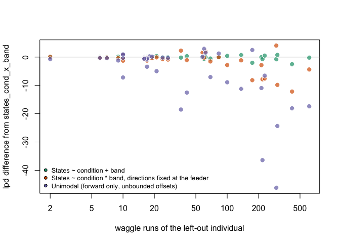

```r
if(file.exists(kfold_file))
{
  runs_ind = tapply(kf$n_runs, kf$individual, max)[rownames(diff_ind)]
  others = setdiff(names(elpd), best)
  kfold_cols = setNames(c('#1b9e77', '#d95f02', '#7570b3', '#e7298a')[seq_along(others)], others)
  plot(NULL, xlim = range(runs_ind), ylim = range(diff_ind[, others]), log = 'x',
       xlab = 'waggle runs of the left-out individual', ylab = paste('lpd difference from', best))
  abline(h = 0, col = 'gray')
  for(m in others)
  {
    points(runs_ind, diff_ind[, m], pch = 21, bg = adjustcolor(kfold_cols[m], 0.7), col = 'white', cex = 1.3)
  }
  legend('bottomleft', legend = model_labels[others], pt.bg = kfold_cols, pch = 21, bty = 'n', cex = 0.8)
}
```

# Hypothesis tests

Each hypothesis in *Hypotheses* is tested with the posterior of the summarised model (population level, typical individual). `P` is the posterior probability that the stated test is true. For directions, `|dmu| - |base| (°)` is the absolute difference in forward direction minus that between horizontal and vertical dances at medium elevation (the baseline), draw by draw; `P` for `<= 0` near 0.5 or above means as similar as the baseline. Tests whose groups were not fitted (e.g. a single-elevation model, or zenith dances) are left out.

```r
#one row of the hypothesis table: posterior summary of draws x, and P(test)
HypRow = function(hypothesis, quantity, x, test, p, circ = FALSE)
{
  q = if(circ){QDegDraws(x)}else{QDraws(x, digits = 3)}
  data.frame(hypothesis = hypothesis, quantity = quantity,
             median = q[1], lower = q[2], upper = q[3],
             test = test, P = round(mean(p), 3),
             row.names = NULL)
}
Has = function(...){all(c(...) %in% groups)}
St = function(g, s){pop_draws[[g]]$p[, s]}
W1 = function(g){pop_draws[[g]]$w1}
DMu = function(g1, g0){mod_circular(pop_draws[[g1]]$mu - pop_draws[[g0]]$mu)}
#group name for a band and condition (for a single-elevation model, only its own band)
pfx = if(joint){function(b, cnd){paste(b, cnd, sep = '_')}}else{function(b, cnd){if(b == params$elevation){cnd}else{NA}}}

#baseline for similar directions: horizontal - vertical at medium elevation
g_bv = pfx('medium', 'vertical'); g_bh = pfx('medium', 'horizontal')
base_dmu = if(Has(g_bv, g_bh)){DMu(g_bh, g_bv)}else{NULL}
#is the direction difference g1 - g0 no larger than the baseline?
Similar = function(h, g1, g0)
{
  if(is.null(base_dmu) || !Has(g1, g0)){return(list())}
  x = abs(deg(DMu(g1, g0))) - abs(deg(base_dmu))
  list(HypRow(h, paste0('mu ', g1, ' - ', g0, ' (°)'), DMu(g1, g0), '', NA, circ = TRUE),
       HypRow(h, '|dmu| - |base| (°)', x, '<= 0', x <= 0))
}
#a condition points away from the feeder
Away = function(h, g)
{
  list(HypRow(h, paste('w1', g), W1(g), 'w1 < 0.5', W1(g) < 0.5),
       HypRow(h, 'P(reversed) - P(forward)', St(g, 'reversed') - St(g, 'forward'), '> 0',
              St(g, 'reversed') > St(g, 'forward')))
}

hyp_rows = list()
#1. medium: vertical and horizontal point in similar directions (the baseline)
if(Has(g_bv, g_bh))
{
  h = '1. medium: V ~ H (baseline)'
  hyp_rows = c(hyp_rows, list(
    HypRow(h, paste('w1', g_bv), W1(g_bv), 'w1 > 0.5', W1(g_bv) > 0.5),
    HypRow(h, paste('w1', g_bh), W1(g_bh), 'w1 > 0.5', W1(g_bh) > 0.5),
    HypRow(h, 'baseline: mu H - V (°)', base_dmu, '', NA, circ = TRUE)))
}
#2. medium and high: solar points away from the feeder, on the vertical axis
for(b in c('medium', 'high'))
{
  gs = pfx(b, 'solar'); gv = pfx(b, 'vertical')
  if(!Has(gs)){next}
  h = paste0('2. ', b, ': solar away')
  hyp_rows = c(hyp_rows, Away(h, gs))
  if(Has(gv))
  {
    hyp_rows = c(hyp_rows, list(
      HypRow(h, 'w1 solar - vertical', W1(gs) - W1(gv), '< 0', W1(gs) < W1(gv))),
      Similar(h, gs, gv))
  }
}
#3. low: horizontal (and zenith) dances are bimodal, on the vertical axis
gv = pfx('low', 'vertical')
for(cnd in c('horizontal', 'zenith'))
{
  g = pfx('low', cnd)
  if(!Has(g)){next}
  h = paste0('3. low: ', cnd, ' bimodal')
  hyp_rows = c(hyp_rows, list(
    HypRow(h, 'P(axial)', St(g, 'axial'), '> 0.5', St(g, 'axial') > 0.5),
    HypRow(h, 'P(axial) - P(forward)', St(g, 'axial') - St(g, 'forward'), '> 0',
           St(g, 'axial') > St(g, 'forward'))))
  if(Has(gv))
  {
    hyp_rows = c(hyp_rows, list(
      HypRow(h, 'P(axial) - vertical', St(g, 'axial') - St(gv, 'axial'), '> 0',
             St(g, 'axial') > St(gv, 'axial'))),
      Similar(h, g, gv))
  }
}
#4. high: horizontal dances point away from the feeder, on the vertical axis
g = pfx('high', 'horizontal')
if(Has(g))
{
  h = '4. high: horizontal away'
  hyp_rows = c(hyp_rows, Away(h, g))
  if(Has(g_bh))
  {
    hyp_rows = c(hyp_rows, list(
      HypRow(h, 'w1 high - medium horizontal', W1(g) - W1(g_bh), '< 0', W1(g) < W1(g_bh))))
  }
  hyp_rows = c(hyp_rows, Similar(h, g, pfx('high', 'vertical')))
}
#5. medium and high: antisolar dances point towards the feeder, like vertical dances
for(b in c('medium', 'high'))
{
  ga = pfx(b, 'antisolar')
  if(!Has(ga)){next}
  h = paste0('5. ', b, ': antisolar towards')
  hyp_rows = c(hyp_rows, list(HypRow(h, paste('w1', ga), W1(ga), 'w1 > 0.5', W1(ga) > 0.5)),
               Similar(h, ga, pfx(b, 'vertical')))
}
#6. solar and antisolar dances share the same axis
for(b in c('medium', 'high'))
{
  hyp_rows = c(hyp_rows, Similar(paste0('6. ', b, ': S ~ A axis'), pfx(b, 'solar'), pfx(b, 'antisolar')))
}
hypothesis_table = do.call(rbind, hyp_rows)
print(hypothesis_table)
```

```
##                      hypothesis                                  quantity
## 1   1. medium: V ~ H (baseline)                        w1 medium_vertical
## 2   1. medium: V ~ H (baseline)                      w1 medium_horizontal
## 3   1. medium: V ~ H (baseline)                    baseline: mu H - V (°)
## 4         2. medium: solar away                           w1 medium_solar
## 5         2. medium: solar away                  P(reversed) - P(forward)
## 6         2. medium: solar away                       w1 solar - vertical
## 7         2. medium: solar away     mu medium_solar - medium_vertical (°)
## 8         2. medium: solar away                        |dmu| - |base| (°)
## 9           2. high: solar away                             w1 high_solar
## 10          2. high: solar away                  P(reversed) - P(forward)
## 11          2. high: solar away                       w1 solar - vertical
## 12          2. high: solar away         mu high_solar - high_vertical (°)
## 13          2. high: solar away                        |dmu| - |base| (°)
## 14   3. low: horizontal bimodal                                  P(axial)
```

[output cut: 53 more lines]

```r
if(is.null(base_dmu))
{
  print('No medium-elevation vertical and horizontal dances in this model, so directions are not compared with the baseline.')
}
if(!Has(pfx('low', 'zenith')))
{
  print('Zenith dances were not included in this model, so hypothesis 3 is tested for horizontal dances only.')
}
```

```
## [1] "Zenith dances were not included in this model, so hypothesis 3 is tested for horizontal dances only."
```

## Conclusions

For the joint model (`states_cond_x_band`, the best model on K-fold cross-validation; full-data fit of 2026 11 09, K-fold of 2026 11 06). Numbers are medians (95% intervals) and posterior probabilities `P` from *Hypothesis tests*, *Population-level predictions* and *Effects of condition*.

- **Model comparison.** Predicting the dances of new bees, the state models were far better than the unimodal null model (229, SE 66), so reversed and bimodal dances are a real feature of the data, not described as well by forward dances with variable directions. Directions fixed at the feeder were clearly worse than estimated directions (−55, SE 21).
- **1. Medium elevations, vertical and horizontal (baseline).** Both were predominantly forward ($w_1$ 0.98 and 0.92, P = 1.00), with few reversed or axial dances, and their forward directions differed by −33° (−41° to −25°; −24° vs +9° from the feeder). This sets a broad baseline: differences of up to about 40° count as “similar”.
- **2. Solar dances point away from the feeder: supported at high elevation, and at medium elevation with slightly less certainty.** High: reversed 0.95 (0.78–0.99), $w_1$ 0.02 (0.00–0.11), P($w_1 < 0.5$) = 1.00. Medium: reversed 0.72 (0.38–0.92), $w_1$ 0.22 (0.05–0.51), P($w_1 < 0.5$) = 0.97, P(reversed > forward) = 0.99. At both elevations the solar axis was closer to the vertical direction than the baseline (+18°, +1° to +35°, P = 0.94; and +18°, +5° to +35°, P = 0.94), as expected for a 180° turn.
- **3. Low elevations, horizontal dances bimodal: supported** (zenith dances not tested). Axial was the most likely state (0.58, 0.41–0.75; P(axial > forward) = 0.96), though whether it is a majority is less certain (P(axial > 0.5) = 0.83). Axial dances were far more likely than for vertical dances (+0.54, 0.36–0.71, P = 1.00) or for horizontal dances at medium elevation (+0.50). Their axis differed from vertical by about as much as the baseline (−31°, −39° to −23°, P = 0.68). Axial dances were asymmetric: 73% (69%–74%) of their runs pointed forward, close to the upper bound of 75%. Reversed dances were rare at low elevations (0.06, 0.00–0.17): there the departure from forward dances is bimodality, not reversal.
- **4. High elevations, horizontal dances point away from the feeder: supported, less clearly than for solar dances.** Reversed 0.63 (0.34–0.84), forward 0.26 (0.09–0.51), $w_1$ 0.31 (0.11–0.59), P($w_1 < 0.5$) = 0.92, P(reversed > forward) = 0.92. $w_1$ was much lower than at medium elevation (−0.61, −0.81 to −0.33, P = 1.00), and the axis differed from vertical by about as much as the baseline (−28°, −43° to −13°, P = 0.74).
- **5. Antisolar dances point towards the feeder: supported.** Medium: $w_1$ 0.83 (0.69–0.92, P = 1.00), reversed 0.06, though a third of dances were axial (0.34). High: $w_1$ 0.71 (0.49–0.87, P = 0.97), with more reversed dances (0.23, 0.08–0.45). Directions were closer to vertical than the baseline (−14°, −29° to +16°, P = 0.99; and +17°, +4° to +29°, P = 0.98).
- **6. Solar and antisolar on the same axis: supported at high elevation, as similar as the baseline at medium.** High: +2° (−15° to +22°, P = 1.00). Medium: +30° (−1° to +52°, P = 0.59), about the size of the baseline.
- **Limitations.** The baseline is broad, so “similar” admits differences of 30°–40°; some pairs not covered by the hypotheses differ by more (e.g. high antisolar − high horizontal, +45°, +26° to +63°). Zenith dances were not modelled. Whether state probabilities depend on elevation at all rests on PSIS-LOO (condition-only states −38, SE 10; unreliable, see *Model comparison*) and the band contrasts, since `states_cond` was not included in K-fold cross-validation. The medium-antisolar direction mixed least well ($\hat{R}$ = 1.08, bulk ESS 71), so its interval is the least precise.

# Appendix

## Individual direction offsets

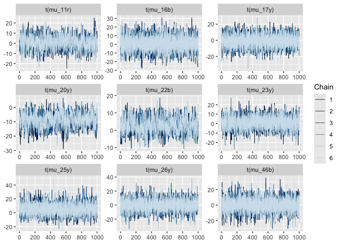

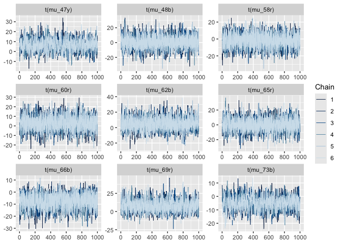

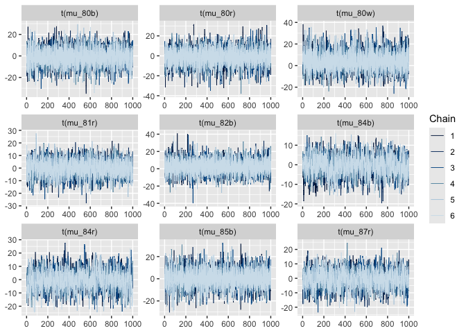

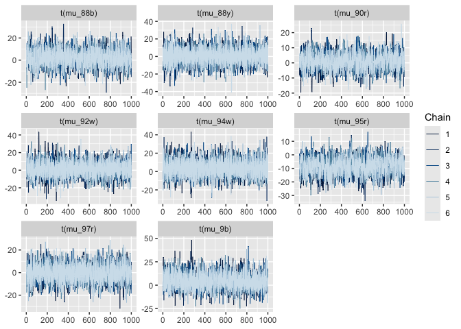

```r
ind_df = posterior::as_draws_df(
  data.frame(.chain = rep(1:n_chains, each = n_draws),
             .iteration = rep(1:n_draws, times = n_chains),
             setNames(as.data.frame(mu_ind), paste0('mu_', id_tab$Individual_label)),
             check.names = FALSE))
plt_panels = 9
for(id in 0:(ceiling(n_ind/plt_panels) - 1))
{
  idx = (id * plt_panels + 1):min((id + 1) * plt_panels, n_ind)
  print(mcmc_trace(ind_df, pars = paste0('mu_', id_tab$Individual_label[idx]),
                   facet_args = list(ncol = 3, nrow = 3),
                   transformations = function(x){deg(x)}))
}
```